Student IDs: 222303/s230951/s223190

```python
import numpy as np
from matplotlib import pyplot as plt
import scipy.sparse as sp
from FEMsolver2d import L2_error_estimator
```

# 2.1

a) Function constructing VX and VY

```python
def xy(x0, y0, L1, L2, noelms1, noelms2):
    lx = L1 / noelms1
    ly = L2 / noelms2

    VX = np.repeat([x0 + i * lx for i in range(noelms1 + 1)], noelms2 + 1)
    VY = [y0 + j * ly for j in range(noelms2,-1,-1)] * (noelms1 + 1)

    return np.array(VX), np.array(VY)
```

```python
#test case
(x0, y0) = (-2.5,-4.8)
L1 = 7.6
L2 = 5.9
noelms1 = 4
noelms2 = 3

VX,VY = xy(x0,y0,L1,L2,noelms1,noelms2)

print(VX)
print(VY)

print(len(VX))
print(len(VY))
```

```
[-2.5 -2.5 -2.5 -2.5 -0.6 -0.6 -0.6 -0.6  1.3  1.3  1.3  1.3  3.2  3.2
  3.2  3.2  5.1  5.1  5.1  5.1]
[ 1.1        -0.86666667 -2.83333333 -4.8         1.1        -0.86666667
 -2.83333333 -4.8         1.1        -0.86666667 -2.83333333 -4.8
  1.1        -0.86666667 -2.83333333 -4.8         1.1        -0.86666667
 -2.83333333 -4.8       ]
20
20
```

b) Function constructing EToV

```python
def conelmtab(noelms1,noelms2):
    EToV = []
    for j in range(noelms1):
        for i in range(noelms2):
            EToV.append([i+noelms2+1+(noelms2+1)*j,i+(noelms2+1)*j, i+noelms2+2+(noelms2+1)*j])
            EToV.append([i+1+(noelms2+1)*j,i+noelms2+2+(noelms2+1)*j,i+(noelms2+1)*j])

    return np.array(EToV)

EToV = conelmtab(4,3)

print(EToV)
```

```
[[ 4  0  5]
 [ 1  5  0]
 [ 5  1  6]
 [ 2  6  1]
 [ 6  2  7]
 [ 3  7  2]
 [ 8  4  9]
 [ 5  9  4]
 [ 9  5 10]
 [ 6 10  5]
 [10  6 11]
 [ 7 11  6]
 [12  8 13]
 [ 9 13  8]
 [13  9 14]
 [10 14  9]
 [14 10 15]
 [11 15 10]
 [16 12 17]
 [13 17 12]
 [17 13 18]
 [14 18 13]
 [18 14 19]
 [15 19 14]]
```

# 2.2

a) basis function.

```python
def basfun(n,VX,VY,EToV):
    idx1 = EToV[n,0]
    idx2 = EToV[n,1]
    idx3 = EToV[n,2]

    x1 = VX[idx1]
    x2 = VX[idx2]
    x3 = VX[idx3]

    y1 = VY[idx1]
    y2 = VY[idx2]
    y3 = VY[idx3]

    delta = 1/2*(x2*y3 - x3*y2 - x1*y3 + x3*y1 + x1*y2 - x2*y1)

    abc = np.zeros((3,3))

    abc[0,0] = x2*y3 - x3*y2
    abc[0,1] = y2 - y3
    abc[0,2] = x3 - x2

    abc[1,0] = x3*y1 - x1*y3
    abc[1,1] = y3 - y1
    abc[1,2] = x1 - x3

    abc[2,0] = x1*y2 - x2*y1
    abc[2,1] = y1 - y2
    abc[2,2] = x2 - x1


    return delta, abc


(x0, y0) = (-2.5,-4.8)
L1 = 7.6
L2 = 5.9
noelms1 = 4
noelms2 = 3

VX,VY = xy(x0,y0,L1,L2,noelms1,noelms2)
EToV = conelmtab(noelms1,noelms2)

delta, abc = basfun(3,VX,VY,EToV)

print(delta)
print(abc)
```

```
1.8683333333333327
[[-6.56333333 -1.96666667 -1.9       ]
 [ 4.91666667  1.96666667  0.        ]
 [ 5.38333333  0.          1.9       ]]
```

b) normal vector component function

```python
def outernormal(n,k,VX,VY,EToV):
    idx1 = EToV[n,(k % 3)]
    idx2 = EToV[n,((k + 1) % 3)]

    dx = VX[idx2] - VX[idx1]
    dy = VY[idx2] - VY[idx1]

    n = np.array([-dy,dx])/np.sqrt(dx*dx+dy*dy)

    return n

outernormal(3,1,VX,VY,EToV)
```

```
array([-0.71919139, -0.69481202])
```

# 2.3

a) assembly process

```python
def assembly(VX, VY, EToV, lam1,lam2, qt):
    N = len(EToV[:,1])
    M = len(VX)

    nnzmax = 9*N
    ii = np.zeros(nnzmax, dtype=int)
    jj = np.zeros(nnzmax, dtype=int)
    ss = np.zeros(nnzmax)
    b = np.zeros(M)
    count = 0

    for n in range(N):
        delta, abc = basfun(n,VX,VY,EToV)

        i = EToV[n,0]
        j = EToV[n,1]
        k = EToV[n,2]

        triplet = [i,j,k]

        x1 = VX[i]
        x2 = VX[j]
        x3 = VX[k]

        y1 = VY[i]
        y2 = VY[j]
        y3 = VY[k]

        for r in range(3):

            qtilde = 1/3*(qt(x1,y1)+qt(x2,y2)+qt(x3,y3))
            b[triplet[r]] += (np.abs(delta)/3)*qtilde

            for s in range(3):

                k_rs = 1/(4*np.abs(delta))*(lam1*abc[r,1]*abc[s,1]+lam2*abc[r,2]*abc[s,2])

                ii[count] = triplet[r]
                jj[count] = triplet[s]
                ss[count] = k_rs
                count += 1


    A = sp.csr_matrix((ss[:count], (ii[:count], jj[:count])), shape=(M, M))
    return A,b
```

```python
#Test case 1
np.set_printoptions(precision=3)


(x0, y0) = (0,0)
L1 = 1
L2 = 1
noelms1 = 4
noelms2 = 3
q = lambda x,y: 0
lam1 = 1
lam2 = 1

VX,VY = xy(x0,y0,L1,L2,noelms1,noelms2)
EToV = conelmtab(noelms1,noelms2)

A,b = assembly(VX, VY, EToV, lam1,lam2, q)

K = [-4, -1, 0, 1, 4]
for k in K:
    print(np.diag(A.todense(), k=k))
```

```
[-0.667 -1.333 -1.333 -0.667 -0.667 -1.333 -1.333 -0.667 -0.667 -1.333
 -1.333 -0.667 -0.667 -1.333 -1.333 -0.667]
[-0.375 -0.375 -0.375  0.    -0.75  -0.75  -0.75   0.    -0.75  -0.75
 -0.75   0.    -0.75  -0.75  -0.75   0.    -0.375 -0.375 -0.375]
[1.042 2.083 2.083 1.042 2.083 4.167 4.167 2.083 2.083 4.167 4.167 2.083
 2.083 4.167 4.167 2.083 1.042 2.083 2.083 1.042]
[-0.375 -0.375 -0.375  0.    -0.75  -0.75  -0.75   0.    -0.75  -0.75
 -0.75   0.    -0.75  -0.75  -0.75   0.    -0.375 -0.375 -0.375]
[-0.667 -1.333 -1.333 -0.667 -0.667 -1.333 -1.333 -0.667 -0.667 -1.333
 -1.333 -0.667 -0.667 -1.333 -1.333 -0.667]
```

```python
#Test case 2

(x0, y0) = (-2.5, -4.8)
L1 = 7.6
L2 = 5.9
noelms1 = 4
noelms2 = 3
q = lambda x,y: -6*x+2*y-2
lam1 = 1
lam2 = 1

VX,VY = xy(x0,y0,L1,L2,noelms1,noelms2)
EToV = conelmtab(noelms1,noelms2)

A,b = assembly(VX, VY, EToV, lam1,lam2, q)

K = [-4, -1, 0, 1, 4]
for k in K:
    print(np.diag(A.todense(), k=k))
```

```
[-0.518 -1.035 -1.035 -0.518 -0.518 -1.035 -1.035 -0.518 -0.518 -1.035
 -1.035 -0.518 -0.518 -1.035 -1.035 -0.518]
[-0.483 -0.483 -0.483  0.    -0.966 -0.966 -0.966  0.    -0.966 -0.966
 -0.966  0.    -0.966 -0.966 -0.966  0.    -0.483 -0.483 -0.483]
[1.001 2.001 2.001 1.001 2.001 4.002 4.002 2.001 2.001 4.002 4.002 2.001
 2.001 4.002 4.002 2.001 1.001 2.001 2.001 1.001]
[-0.483 -0.483 -0.483  0.    -0.966 -0.966 -0.966  0.    -0.966 -0.966
 -0.966  0.    -0.966 -0.966 -0.966  0.    -0.483 -0.483 -0.483]
[-0.518 -1.035 -1.035 -0.518 -0.518 -1.035 -1.035 -0.518 -0.518 -1.035
 -1.035 -0.518 -0.518 -1.035 -1.035 -0.518]
```

# 2.4

```python
def dirbc(bnodes, f, A, b):
    M = len(b)
    for n,i in enumerate(bnodes):

        if f[n] == None:
            continue

        A[i,i] = 1
        b[i] = f[n]

        for j in range(M):
            if j != i and A[i,j] != 0:
                A[i,j] = 0
                if j not in bnodes:
                    b[j] -= A[j,i]*f[n]
                    A[j,i] = 0

    return A,b
```

```python
def find_bnodes(noelms1,noelms2):
    bnodes = np.arange(noelms2+1)
    for j in range(1,noelms1):
        bnodes = np.append(bnodes, j*(noelms2+1))
        bnodes = np.append(bnodes, j*(noelms2+1) + noelms2)

    bnodes = np.append(bnodes, np.arange((noelms2+1)*noelms1, (noelms2+1)*(noelms1+1)))

    return bnodes
```

```python
(x0, y0) = (0,0)
L1 = 1
L2 = 1
noelms1 = 4
noelms2 = 3
q = lambda x,y: 0
lam1 = 1
lam2 = 1
bnodes = find_bnodes(noelms1,noelms2)
f = np.ones((noelms1+1)*(noelms2+1))

VX,VY = xy(x0,y0,L1,L2,noelms1,noelms2)

EToV = conelmtab(noelms1,noelms2)
A,b = assembly(VX, VY, EToV, lam1,lam2, q)

A, b = dirbc(bnodes, f, A, b)

K = [-4, -1, 0, 1, 4]
for k in K:
    print(np.diag(A.todense(), k=k))
```

```
[ 0.     0.     0.     0.     0.    -1.333 -1.333  0.     0.    -1.333
 -1.333  0.     0.     0.     0.     0.   ]
[ 0.    0.    0.    0.    0.   -0.75  0.    0.    0.   -0.75  0.    0.
  0.   -0.75  0.    0.    0.    0.    0.  ]
[1.    1.    1.    1.    1.    4.167 4.167 1.    1.    4.167 4.167 1.
 1.    4.167 4.167 1.    1.    1.    1.    1.   ]
[ 0.    0.    0.    0.    0.   -0.75  0.    0.    0.   -0.75  0.    0.
  0.   -0.75  0.    0.    0.    0.    0.  ]
[ 0.     0.     0.     0.     0.    -1.333 -1.333  0.     0.    -1.333
 -1.333  0.     0.     0.     0.     0.   ]
```

```python
(x0, y0) = (-2.5, -4.8)
L1 = 7.6
L2 = 5.9
noelms1 = 4
noelms2 = 3
q = lambda x,y: -6*x+2*y-2
lam1 = 1
lam2 = 1
bnodes = find_bnodes(noelms1,noelms2)
f = lambda x,y: x**3 - x**2*y + y**2 - 1

VX,VY = xy(x0,y0,L1,L2,noelms1,noelms2)

EToV = conelmtab(noelms1,noelms2)
A,b = assembly(VX, VY, EToV, lam1,lam2, q)

A, b = dirbc(bnodes, f(VX[bnodes],VY[bnodes]), A, b)

K = [-4, -1, 0, 1, 4]
for k in K:
    print(np.diag(A.todense(), k=k))
```

```
[ 0.     0.     0.     0.     0.    -1.035 -1.035  0.     0.    -1.035
 -1.035  0.     0.     0.     0.     0.   ]
[ 0.     0.     0.     0.     0.    -0.966  0.     0.     0.    -0.966
  0.     0.     0.    -0.966  0.     0.     0.     0.     0.   ]
[1.    1.    1.    1.    1.    4.002 4.002 1.    1.    4.002 4.002 1.
 1.    4.002 4.002 1.    1.    1.    1.    1.   ]
[ 0.     0.     0.     0.     0.    -0.966  0.     0.     0.    -0.966
  0.     0.     0.    -0.966  0.     0.     0.     0.     0.   ]
[ 0.     0.     0.     0.     0.    -1.035 -1.035  0.     0.    -1.035
 -1.035  0.     0.     0.     0.     0.   ]
```

# 2.5

```python
def BVP2D(x0,y0,L1,L2,noelms1,noelms2,qt,lam1,lam2,f):
    VX,VY = xy(x0,y0,L1,L2,noelms1,noelms2)
    EToV = conelmtab(noelms1,noelms2)
    bnodes = find_bnodes(noelms1,noelms2)

    A,b = assembly(VX, VY, EToV, lam1,lam2, qt)
    farr = f(VX[bnodes], VY[bnodes])
    A, b = dirbc(bnodes, farr, A, b)

    u = sp.linalg.spsolve(A,b)

    return u, VX, VY
```

*Test case 1*

For given $U(x,y) = x^3-x^2y+y^2-1$ we find \begin{align} u_{xx} = 6x-2y \\ u_{yy} = 2 \end{align} Which yields for $\tilde{q}(x,y) = -u_{xx} - u_{yy} = -6x + 2y -2$

For $f(x,y)$ we obtain $f(x,y) = x^3-x^2y+y^2-1$ for $(x,y) \in \Gamma $

*Test case 2*

For given $U(x,y) = x^2y^2$ we find \begin{align} u_{xx} = 2y^2 \\ u_{yy} = 2x^2 \end{align} Which yields for $\tilde{q}(x,y) = -u_{xx} - u_{yy} = -2(y^2 + x^2)$

For $f(x,y)$ we obtain $f(x,y) = x^2y^2$ for $(x,y) \in \Gamma $

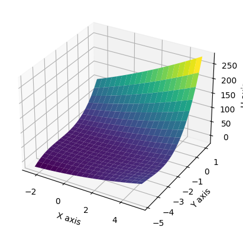

```python
# 3d Plot of test case

(x0, y0) = (-2.5, -4.8)
L1 = 7.6
L2 = 5.9
noelms1 = 20
noelms2 = 20
lam1 = 1
lam2 = 1
q = lambda x,y: -6*x+2*y-2
f = lambda x,y: x**3 - x**2*y + y**2 - 1

u, VX, VY = BVP2D(x0,y0,L1,L2,noelms1,noelms2,q,lam1,lam2,f)

x = VX
y = VY

#%%

# Getting the unique values and sorting them
unique_x = np.unique(x)
unique_y = np.unique(y)

# Reshaping u to match the grid
U = u.reshape(len(unique_y), len(unique_x))

#U_true = lambda x,y: x**3 - x**2 * y + y**2 - 1

# Creating the meshgrid
X, Y = np.meshgrid(unique_x, unique_y)

# Create a figure and a 3D axis
fig = plt.figure()
ax = fig.add_subplot(111, projection='3d')

# Surface plot
surf = ax.plot_surface(X, Y, U, cmap='viridis')

# Labeling
ax.set_xlabel('X axis')
ax.set_ylabel('Y axis')
ax.set_zlabel('U axis')

# Show the plot
plt.show()
```

```python
#Test case 1
(x0, y0) = (-2.5, -4.8)
L1 = 7.6
L2 = 5.9
noelms1 = 4
noelms2 = 3
lam1 = 1
lam2 = 1
q = lambda x,y: -6*x+2*y-2
f = lambda x,y: x**3 - x**2*y + y**2 - 1

u, VX, VY = BVP2D(x0,y0,L1,L2,noelms1,noelms2,q,lam1,lam2,f)

u_exact = f(VX,VY)

E = np.linalg.norm(u-u_exact, np.inf)

print(E)
```

```
2.842170943040401e-14
```

```python
H = np.logspace(0,-1,10)
error = np.zeros(len(H))

(x0, y0) = (-2.5, -4.8)
L1 = 7.6
L2 = 5.9
# noelms1 = 4
# noelms2 = 3
lam1 = 1
lam2 = 1
q = lambda x,y: -6*x+2*y-2
f = lambda x,y: x**3 - x**2*y + y**2 - 1


for i,h in enumerate(H):
    noelms1 = int(L1/h)
    noelms2 = int(L2/h)

    u, VX, VY = BVP2D(x0,y0,L1,L2,noelms1,noelms2,q,lam1,lam2,f)
    u_exact = f(VX,VY)
    error[i] = np.linalg.norm(u-u_exact, np.inf)
```

```python
a,b = np.polyfit(np.log(H), np.log(error), 1)
plt.loglog(H,error,'r--')
```

[output not shown]

```python
#Test case 2

(x0, y0) = (-2.5, -4.8)
L1 = 7.6
L2 = 5.9
noelms1 = 4
noelms2 = 3
lam1 = 1
lam2 = 1
q = lambda x,y: -2*(x**2+y**2)
f = lambda x,y: x**2*y**2

u, VX, VY = BVP2D(x0,y0,L1,L2,noelms1,noelms2,q,lam1,lam2,f)
```

```python
P = list(range(2,7))
error = np.zeros(len(P))

for i,p in enumerate(P):
    noelms1 = 2**p
    noelms2 = 2**p

    u, VX, VY = BVP2D(x0,y0,L1,L2,noelms1,noelms2,q,lam1,lam2,f)
    u_exact = f(VX,VY)
    error[i] = np.linalg.norm(u-u_exact, np.inf)

DOF = [(2**p+1)**2 for p in P]
```

To validate our solver we find an analytical expression for the error \begin{align*} \text{error} = C h^2 \end{align*} then \begin{align*} \log(\text{error}) = \log(C) + 2 \log(h) \end{align*} Let $N$ be the number of elements in the x and y direction. Then the maximal $h$ is given by: \begin{align*} \left(\frac{1}{N}\right)^2 + \left(\frac{1}{N}\right)^2 = h^2 \ \Rightarrow \ h = \frac{\sqrt{2}}{N} \end{align*} Letting $N=2^p$ with p then \begin{align*} \log(\text{error}) &= \log(C) + 2 \log(h) \\ &= \log(C) + 2 \log(\frac{\sqrt{2}}{2^p}) \\ &= \log(C) + 2 \log(2) - 2 \log(2)p \end{align*} with $K = \log(C) + 2 \log(2)$ which is a constant we expect the error to follow the line \begin{align*} \log(\text{error}) = K - 2 \log(2)p \end{align*} a plot of this can be seen below

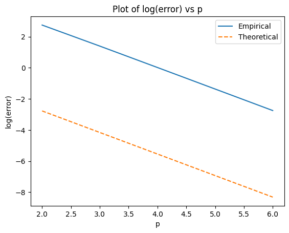

```python
#plt.loglog(DOF,error,'r--')
#plt.semilogy(P,error)
plt.plot(P,np.log(error), label='Empirical')
plt.plot(P,-2*np.log(2)*np.array(P),'--', label='Theoretical')
plt.title("Plot of log(error) vs p")
plt.xlabel("p")
plt.ylabel("log(error)")
plt.legend()
plt.show()
```

# 2.6

*a)*

```python
def ConstructBeds(VX,VY,EToV):

    beds = []

    for n in range(len(EToV[:,1])):
        for k in range(3):
            (i,j) = (EToV[n,(k,((k+1) % 3))])

            mid = np.array([(VX[i]+VX[j])/2, (VY[i]+VY[j])/2])

            if mid[0] <= x0 or mid[0]  >= x0 + L1 or mid[1] <= y0 or mid[1] >= y0 + L2:
                beds.append([n,k])

    return np.array(beds)
```

*b)*

```python
def neubc(VX,VY,EToV,beds,q,b):
    for n,r in beds:
        i, j = EToV[n,(r,((r+1) % 3))]

        xi = VX[i]
        xj = VX[j]
        yi = VY[i]
        yj = VY[j]


        qhat = q( (xi+xj)/2, (yi+yj)/2 )

        if qhat == None:
            continue

        qp = qhat/2*np.sqrt(((xj-xi)*(xj-xi) + (yj-yi)*(yj-yi)))

        b[i] -= qp
        b[j] -= qp

    return b
```

# 2.7

**Testcase 1:** We use the method of manufactured solution to obtain \begin{equation*} \tilde{q} = 0 \end{equation*} and \begin{align*} u_n &= \begin{bmatrix} -1 & 0 \end{bmatrix}\begin{bmatrix} 3 \\ 5 \end{bmatrix} = -3 \text{ on the left edge.} \\ u_n &= \begin{bmatrix} 0 & -1 \end{bmatrix}\begin{bmatrix} 3 \\ 5 \end{bmatrix} = -5 \text{ on the bottom edge.} \end{align*}

thus $q(x,y) = \begin{cases} 3 & left \\ 5 & bottom\end{cases}$

```python
(x0, y0) = (-2.5, -4.8)
L1 = 7.6
L2 = 5.9
noelms1 = 4
noelms2 = 3
lam1 = 1
lam2 = 1
qt = lambda x,y: 0

def q(x,y):
    if np.abs( x-x0 ) < 1e-6:
        return 3
    elif np.abs( y-y0 ) < 1e-6:
        return 5
    else:
        return None

def f(x,y):
    if np.abs( x-(x0+L1) ) < 1e-6 or np.abs( y-(y0+L2) ) < 1e-6:
        return 3*x + 5*y -7
    else:
        return None
```

```python
def BVP2D(x0,y0,L1,L2,noelms1,noelms2,qt,lam1,lam2,f,q):

    VX,VY = xy(x0,y0,L1,L2,noelms1,noelms2)
    EToV = conelmtab(noelms1,noelms2)
    bnodes = find_bnodes(noelms1,noelms2)

    A,b = assembly(VX, VY, EToV, lam1,lam2, qt)

    # Implementing Neumann Boundary Condition
    beds = ConstructBeds(VX,VY,EToV)
    b = neubc(VX,VY,EToV,beds,q,b)

    # Implementing Dirichlet Boundary Condition
    farr = [f(VX[bnodes[i]], VY[bnodes[i]]) for i in range(len(bnodes))]
    A, b = dirbc(bnodes, farr, A, b)

    u = sp.linalg.spsolve(A,b)

    return u, VX, VY

u, VX, VY = BVP2D(x0,y0,L1,L2,noelms1,noelms2,qt,lam1,lam2,f,q)
```

We estimate the $\mathcal{L}^2$ error by interpolating $\hat{u}$ on a $100\times100$ grid and comparing to the solution evaluated on the same grid by computing $\sqrt{\sum_{i,j} (\hat{u}(x_i,y_j) - u(x_i,y_j))^2}$

```python
ufun = lambda x,y: 3*x + 5*y - 7
L2_error_estimator(VX,VY,u,ufun,M=100)
```

```
9.467013266493787e-13
```

The error is extremely small even though we are on a quite coarse grid. This is because we are trying to estimate a polynomial of order one by polynomials of order one, so we get the exact solution.

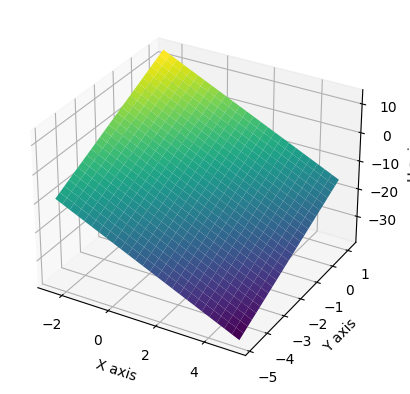

```python
# 3d Plot of test case
x = VX
y = VY

#%%

# Getting the unique values and sorting them
unique_x = np.unique(x)
unique_y = np.unique(y)

# Reshaping u to match the grid
U = u.reshape(len(unique_y), len(unique_x))

#U_true = lambda x,y: x**3 - x**2 * y + y**2 - 1

# Creating the meshgrid
X, Y = np.meshgrid(unique_x, unique_y)

# Create a figure and a 3D axis
fig = plt.figure()
ax = fig.add_subplot(111, projection='3d')

# Surface plot
surf = ax.plot_surface(X, Y, U, cmap='viridis')

# Labeling
ax.set_xlabel('X axis')
ax.set_ylabel('Y axis')
ax.set_zlabel('U axis')

# Show the plot
plt.show()
```

When performing a convergence test, we see that we can not improve the error. On the contraty, it grows as we are solving larger and larger linear systems and introducing computational errors.

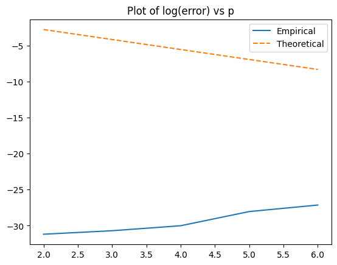

```python
ufun = lambda x,y: 3*x + 5*y - 7

P = list(range(2,7))
error = np.zeros(len(P))

for i,p in enumerate(P):
    noelms1 = 2**p
    noelms2 = 2**p

    u, VX, VY = BVP2D(x0,y0,L1,L2,noelms1,noelms2,qt,lam1,lam2,f,q)
    u_exact = ufun(VX,VY)
    error[i] = np.linalg.norm(u-u_exact, np.inf)

DOF = [(2**p+1)**2 for p in P]

#plt.loglog(DOF,error,'r--')
#plt.semilogy(P,error)
plt.plot(P,np.log(error), label='Empirical')
plt.plot(P,-2*np.log(2)*np.array(P),'--', label='Theoretical')
plt.title("Plot of log(error) vs p")
plt.xlabel("p")
plt.ylabel("log(error)")
plt.legend()
plt.show()
```

**Testcase 2:** We use the method of manufactured solution to obtain \begin{equation*} \tilde{q}(x,y) = 2\sin(x)\sin(y) \end{equation*}

\begin{equation*} f(x,y) = \sin(x)\sin(y) \quad (x,y) \in \Gamma_2 \end{equation*}

and \begin{equation*} q(x,y) = \begin{cases} \cos(x)\sin(y) & (x,y)\in \Gamma_1 \text{ left} \\ \sin(x)\cos(y) & (x,y)\in \Gamma_1 \text{ bottom} \end{cases} \end{equation*}

```python
(x0, y0) = (-2.5, -4.8)
L1 = 7.6
L2 = 5.9
noelms1 = 32
noelms2 = 32
lam1 = 1
lam2 = 1

qt = lambda x,y: 2*np.sin(x)*np.sin(y)

def q(x,y):
    if np.abs( x-x0 ) < 1e-6:
        return np.cos(x)*np.sin(y)
    elif np.abs( y-y0 ) < 1e-6:
        return np.cos(y)*np.sin(x)
    else:
        return None

def f(x,y):
    if np.abs( x-(x0+L1) ) < 1e-6 or np.abs( y-(y0+L2) ) < 1e-6:
        return np.sin(x)*np.sin(y)
    else:
        return None
```

```python
def BVP2D(x0,y0,L1,L2,noelms1,noelms2,qt,lam1,lam2,f,q):

    VX,VY = xy(x0,y0,L1,L2,noelms1,noelms2)
    EToV = conelmtab(noelms1,noelms2)
    bnodes = find_bnodes(noelms1,noelms2)

    A,b = assembly(VX, VY, EToV, lam1,lam2, qt)

    # Implementing Neumann Boundary Condition
    beds = ConstructBeds(VX,VY,EToV)
    b = neubc(VX,VY,EToV,beds,q,b)

    # Implementing Dirichlet Boundary Condition
    farr = [f(VX[bnodes[i]], VY[bnodes[i]]) for i in range(len(bnodes))]
    A, b = dirbc(bnodes, farr, A, b)

    u = sp.linalg.spsolve(A,b)

    return u, VX, VY

u, VX, VY = BVP2D(x0,y0,L1,L2,noelms1,noelms2,qt,lam1,lam2,f,q)
```

We estimate the $\mathcal{L}^2$ error as before

```python
ufun = lambda x,y: np.sin(x)*np.sin(y)
L2_error_estimator(VX,VY,u,ufun,M=100)
```

```
1.2359154024508991
```

This is larger than befor, but still not too bad. We also have relatively high resolution.

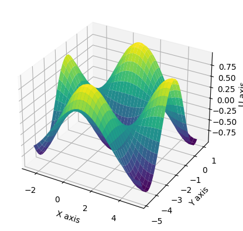

```python
# 3d Plot of test case
x = VX
y = VY

#%%


# Getting the unique values and sorting them
unique_x = np.unique(x)
unique_y = np.unique(y)

# Reshaping u to match the grid
U = u.reshape(len(unique_y), len(unique_x))

#U_true = lambda x,y: x**3 - x**2 * y + y**2 - 1

# Creating the meshgrid
X, Y = np.meshgrid(unique_x, unique_y)

# Create a figure and a 3D axis
fig = plt.figure()
ax = fig.add_subplot(111, projection='3d')

# Surface plot
surf = ax.plot_surface(X, Y, U, cmap='viridis')

# Labeling
ax.set_xlabel('X axis')
ax.set_ylabel('Y axis')
ax.set_zlabel('U axis')

# Show the plot
plt.show()
```

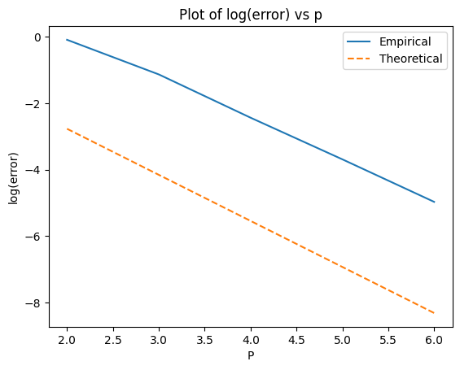

```python
ufun = lambda x,y: np.sin(x)*np.sin(y)

P = list(range(2,7))
error = np.zeros(len(P))

for i,p in enumerate(P):
    noelms1 = 2**p
    noelms2 = 2**p

    u, VX, VY = BVP2D(x0,y0,L1,L2,noelms1,noelms2,qt,lam1,lam2,f,q)
    u_exact = ufun(VX,VY)
    error[i] = np.linalg.norm(u-u_exact, np.inf)

DOF = [(2**p+1)**2 for p in P]

#plt.loglog(DOF,error,'r--')
#plt.semilogy(P,error)
plt.plot(P,np.log(error), label='Empirical')
plt.plot(P,-2*np.log(2)*np.array(P),'--', label='Theoretical')
plt.title("Plot of log(error) vs p")
plt.xlabel("P")
plt.ylabel("log(error)")
plt.legend()
plt.show()
```